# White Wine Dataset Exploratory Data Analysis, by Emad Takla

# Multivariate Plots Section

**NB: The coloring code that will be used through this section is the same as the previous section. Here is a reminder:**

** Wine Quality:**

** - High Quality: Green**

** - Medium Quality: Yellow**

** - Low Quality: Red**

**Wine Alcohol Content:**

** - High Alcohol: Green**

** - Medium Alcohol: Yellow**

** - Low Alcohol: Red**

## Quality

### Quality Versus Alcohol Percentage and Total Sulfur Dioxide

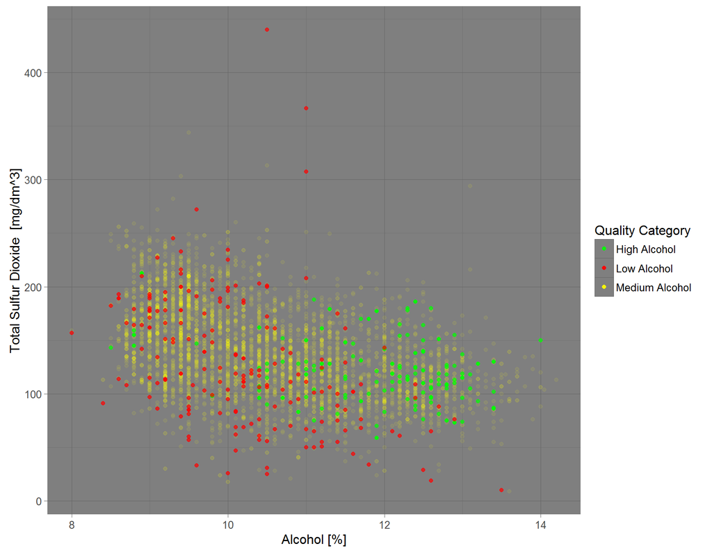

### Quality Versus Saltiness (Chlorides) and Sweetness (Residual Sugar)

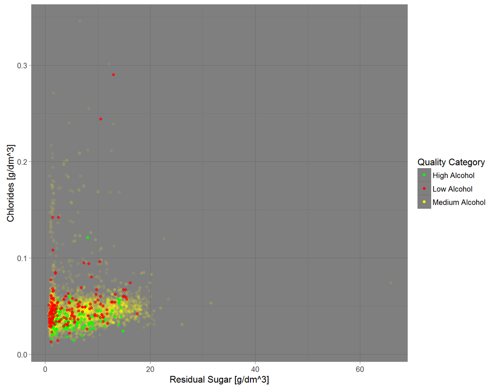

### Quality Versus the Two Types of Acidity

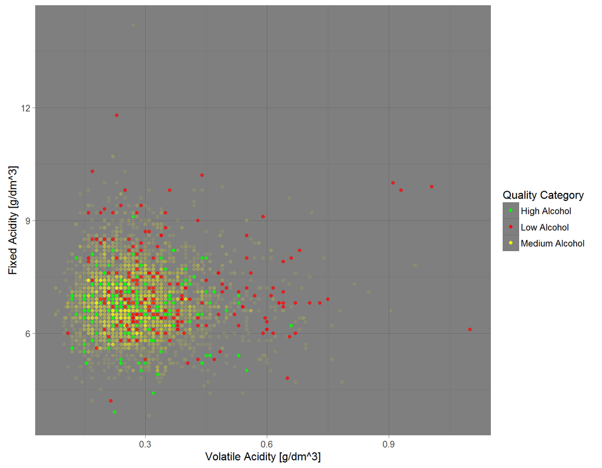

## Alcohol

### Alcohol Versus Saltiness (Chlorides) and Sweetness (Residual Sugar)

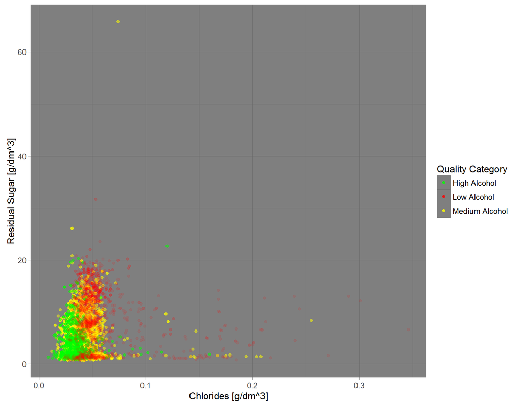

### Alcohol Versus Quality and Total Sulfur Dioxide

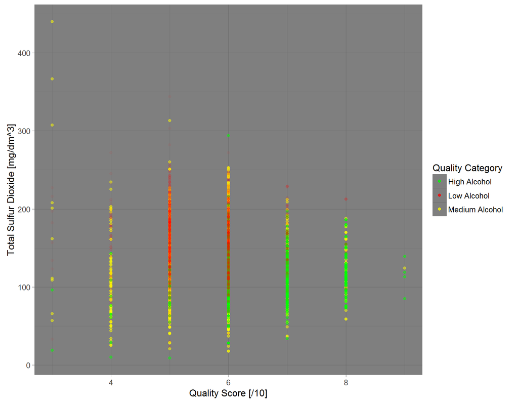

This graph is confirming what is already known, but I like how it transfers the information, sort of spectrum bands, like light components analysis. But I think adding a jitter will make us see more details of the structure of each column.

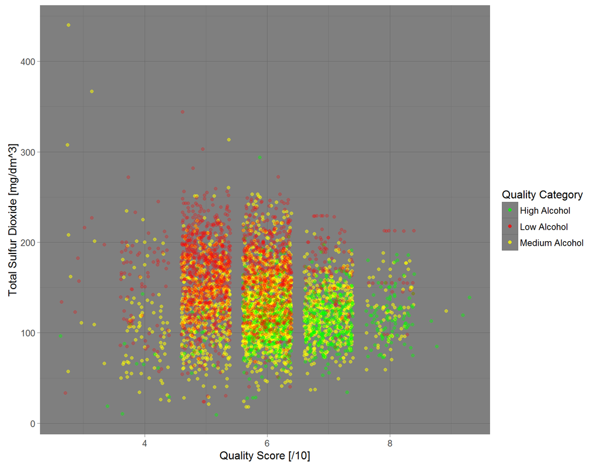

I like this visualization, I will repeat it but this time it will be for the total content of the trio degrading elements, that is voltaile acidity (Vinegar taste), chlorides (saltiness) and total sulfur dioxide (matches taste).

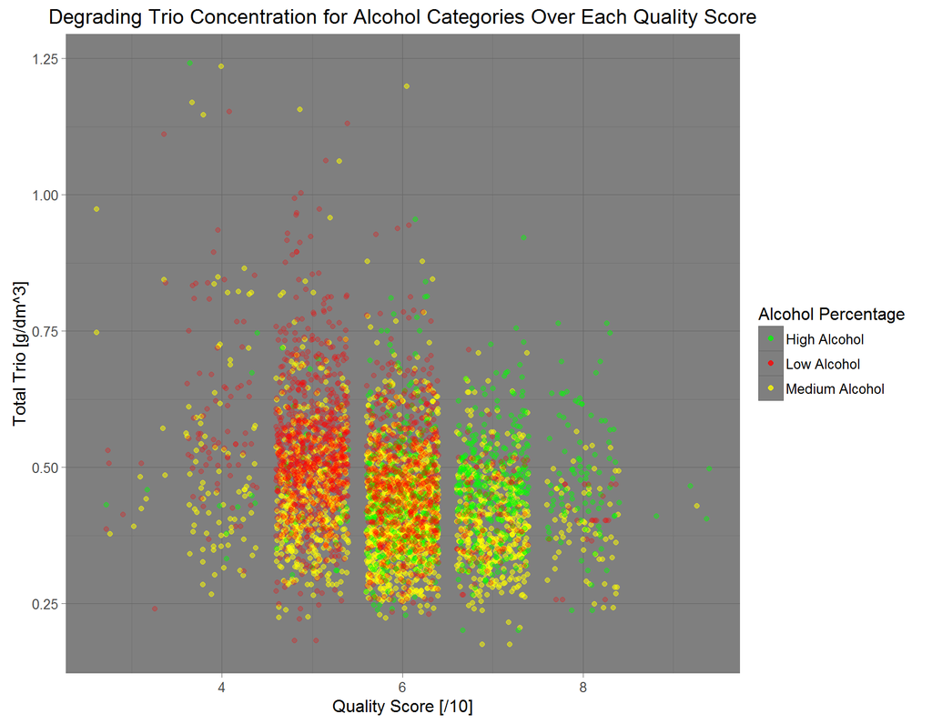

This last graph by itself may not be that interesting, but what I find eye catching is when I have compared it to the one before: High Alcohol wines dots moved higher, and the medium and low alcohol bottles moved lower. I find this metric (the degrading trio) interesting, but still I would take it with a grain of salt. Numerically, the whole metric is highly dominated by the volatile acidity and this is the part that makes me doubt it a bit. But the pro for this metric is that it has a better correlation coefficient with quality than any of its constituant alone.

# Multivariate Analysis

### Talk about some of the relationships you observed in this part of the investigation. Were there features that strengthened each other in terms of looking at your feature(s) of interest?

For the aclohol level, the multivariate analysis just confirmed what was already induced from previous plots, with the highest quality scores (6 and onwards) having a noticeable higher alcohol wines.

### Were there any interesting or surprising interactions between features?

Although that for the most part you can visually distinguish that high quality and low quality wines occupied different regions, the medium quality wine overlapped with both regions - which casted some doubt over my selection criteria for quality. Of course there is also the numbers game effect, the amount of medium quality wine was huge compared to the other two categories, so maybe this is just the effect of the extreme imbalance in terms of quality within the sample. I thought of changing my ranking method to be: bad wine <= 5/10, medium wine = 6, high quality >= 7 so that I would get a more equal distribution among the three different categories, but after some thinking, I would not call a 5/10 wine to be of a bad quality, and would not call a 7 to be of excellent quality. But on the other hand, if I was working on a classification model, I would have picked that newer method, I think it would have led to a more accurate classification.

### OPTIONAL: Did you create any models with your dataset? Discuss the strengths and limitations of your model.

I have not yet, but I think I will work over that problem with my preferred tools for that task: Python and SciKit Learn. I am suspecting that the best two factors to be used for predicting quality are Alcohol Percentage and the total of Chlorides, Volatile Acidity and Total Sulfur Dioxide (in grams/dm^3). Density might seem a good candidate, but since we have included the top density affecting elements already, and that density is also strongly affected by residual sugars which show no correlation at all with quality, I think it might actually be better to exclude it. I can use too citric acid, since it looks like having a very defining window for wine quality.

# Final Plots and Summary

### Plot One

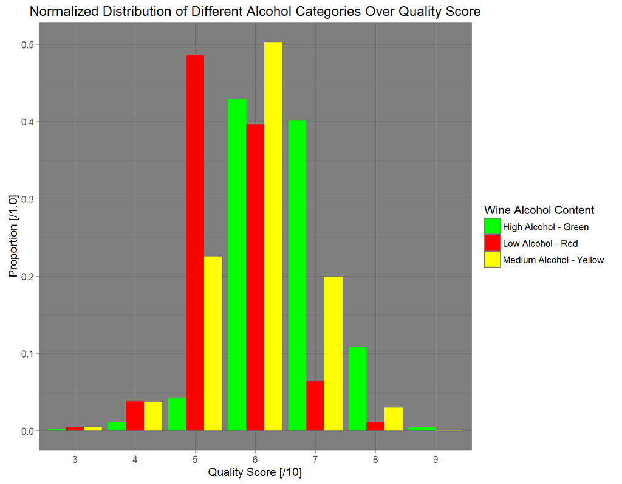

### Description One

After splitting wines into three categories in terms of alcohol content, the distribution of each category over quality scores showed an interesting trend: - High and Medium alcohol bottles had a peak at score of 6, while low alcohol had its peak t a lower score, 5 - Low alcohol wine had a very prominenet skewness, leaning towards the worst scores. Although that medium and high alcohol had a lot more regular shapes, the medium alcohol was slightly skewed towards the lesser scores while the higher alcohol were slightly skewed towards the higher scores. - All scores had candidates from all categories, except for the best available score (9), That one had no low alcohol bottles at all, with the majority of the bottles being from the high alcohol category.

### Plot Two

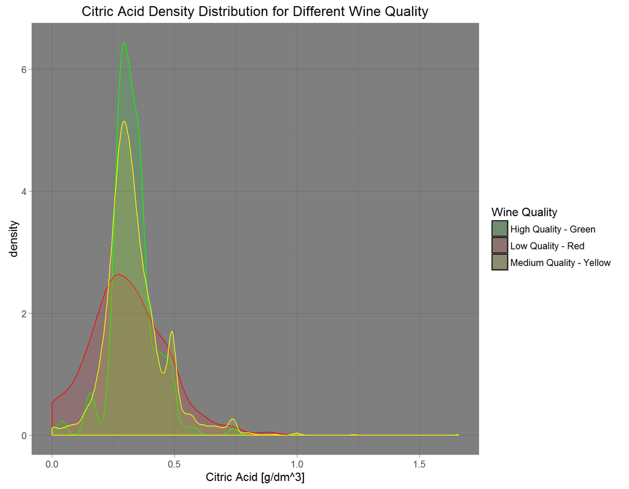

### Description Two

Citric acid can add ‘freshness’ and flavor to wines. When visualising the density distribution of the citric acide in comparison with different qualities, ones get the feeling that there is a narrow window for the “right” amount of citric acid (Roughly between 0.2 and 0.4 ). The higher the wine quality, the more bottles we have concentrated around this window.

### Plot Three

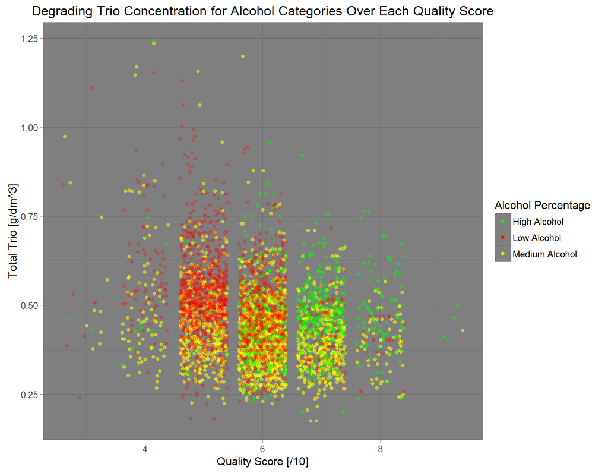

### Description Three

There are three degrading elements for the wine quality, when they are present in noticeable quantities. Acetic acid (Volatile acidity) adds a vinegar like taste, while chlorides make the wine salty. The last factor, sulfur dioxide, has a taste and smell like that of matches. When the three are added to make up a sum in grams per decimeter cube and spread over the different scores, we can notice something interesting regarding the highest scoring bottles: the higher is the alcohol, the more these three degrading elements were tolerated. High scoring bottles that have medium amount of alcohol had a lesser amount of this degrading trio. Higher alcohol bottles are noticeably shifted upwards (Observe score number 8), and generally the higher the point is in this graph, the more likely is that it would be less favourably regarded.

# Reflection

We can see some quality trends in this dataset, although that they are not strong trends. The most noteworthy trends are: - Alcohol level - Volatile acidity - Chlorides - Total amount of sulfur dioxide

These parameters in general make sense, but the other thing that I think is worth discussing here is the quality parameter itself. There is a lot of subjectivity in the notion itself, and people have different tastes and perceive taste differently. Of course with the fact that the graders were wine experts, this reduces a lot the subjectivity, I would have preferred that the quality score would have been broken down into more constituants, or at least there would be an explanation about how this score was calculated.

Also, I would have liked to examine the relationship between the price, geography and weather of the vinyard, total sales and the quality. But these factors were ommitted for privacy and logistical reasons.

My last reflection, this time it is not about this dataset but about the project in general: I have started by picking a fairly complicated dataset, about astronomy. I struggled a lot with the analysis, and have spendt a lot of time trying to gain a good understanding about the patterns found. I have learned a lot, but I have felt that this is not going anywhere unless I can get a good subject matter knowledge support. When I have switched to the wine dataset, life was a lot easier. So my last reflection would be about the field expertise; the more we have about it, the more the EDA process is less cumbersome.